# SI 618 - Homework #7: Classifiers

or: How I Learned to Stop Worrying and Love Machine Learning

Version 2023.11.08.1.CT

This is, perhaps, one of the most exciting homework assignments that you have encountered in this course!

You are going to try your hand at a Kaggle competition to predict which passengers on board the Spaceship Titanic are transported to an alternate dimension.

You can access the competition here: **https://www.kaggle.com/c/spaceship-titanic**

This assignment is similar to the Kaggle competition that we did in class, but it uses a different and larger dataset.

The basic steps for this assignment are the same as what we did in class:

1. Accept the rules and join the competition
2. Download the data (from the data tab of the competition page)
3. Understand the problem
4. EDA (Exploratory Data Analysis)
5. Train, tune, and ensemble (!) your machine learning models
6. Upload your prediction as a submission on Kaggle and receive an accuracy score

additionally, you will

7. Upload your final notebook to Canvas and report your best accuracy score.

Note that class grades are not entirely dependent on your accuracy score.  
All models that achieve 80% accuracy will receive full points for the accuracy component of this assignment.

Rubric:

1. (20 points) Conduct an EDA. You must demonstrate that you understand the data and the problem.
2. (60 points) Train, tune, and ensemble machine learning models. You must use at least 3 different models, and you must ensemble them in some way. You must also tune your models to improve accuracy.
3. (10 points) Accuracy score based on Kaggle submission report (or alternative, see NOTE above).
4. (10 points) PEP-8, grammar, spelling, style, etc.

Some additional notes:

1. If you use another notebook, code, or approaches be sure to reference the original work. (Note that we recommend you study existing Kaggle notebooks before starting your own work.)
2. You can help each other but in the end you must submit your own work, both to Kaggle and to Canvas.

Some additional resources:

- "ensemble" your models with a [VotingClassifier](https://scikit-learn.org/stable/modules/generated/sklearn.ensemble.VotingClassifier.html)
- a good primer on [feature engineering](https://triangleinequality.wordpress.com/2013/09/08/basic-feature-engineering-with-the-titanic-data/)
- There are a lot of good [notebooks to study](https://www.kaggle.com/competitions/spaceship-titanic/code) (check the number of upvotes to help guide your exploration), but be careful to cite any code that you use, and be careful to not accidentally (or intentionally) cheat.

## GOOD LUCK!

(and don't cheat)

One final note: Your submission should be a self-contained notebook that is NOT based on this one. Studying the existing Kaggle competition notebooks should give you a sense of what makes a "good" notebook.

# Exploratory Data Analyses

```python
import pandas as pd
import seaborn as sns
import matplotlib.pyplot as plt
import numpy as np

sns.set_palette("pastel")
```

```python
titanic_train = pd.read_csv('train.csv')
titanic_test = pd.read_csv('test.csv')
titanic_train.head()
```

|  | PassengerId | HomePlanet | CryoSleep | Cabin | Destination | Age | VIP | RoomService | FoodCourt | ShoppingMall | Spa | VRDeck | Name | Transported |
| --- | --- | --- | --- | --- | --- | --- | --- | --- | --- | --- | --- | --- | --- | --- |
| 0 | 0001_01 | Europa | False | B/0/P | TRAPPIST-1e | 39.0 | False | 0.0 | 0.0 | 0.0 | 0.0 | 0.0 | Maham Ofracculy | False |
| 1 | 0002_01 | Earth | False | F/0/S | TRAPPIST-1e | 24.0 | False | 109.0 | 9.0 | 25.0 | 549.0 | 44.0 | Juanna Vines | True |
| 2 | 0003_01 | Europa | False | A/0/S | TRAPPIST-1e | 58.0 | True | 43.0 | 3576.0 | 0.0 | 6715.0 | 49.0 | Altark Susent | False |
| 3 | 0003_02 | Europa | False | A/0/S | TRAPPIST-1e | 33.0 | False | 0.0 | 1283.0 | 371.0 | 3329.0 | 193.0 | Solam Susent | False |
| 4 | 0004_01 | Earth | False | F/1/S | TRAPPIST-1e | 16.0 | False | 303.0 | 70.0 | 151.0 | 565.0 | 2.0 | Willy Santantines | True |

## General Description

```python
titanic_train.describe()
```

|  | Age | RoomService | FoodCourt | ShoppingMall | Spa | VRDeck |
| --- | --- | --- | --- | --- | --- | --- |
| count | 8514.000000 | 8512.000000 | 8510.000000 | 8485.000000 | 8510.000000 | 8505.000000 |
| mean | 28.827930 | 224.687617 | 458.077203 | 173.729169 | 311.138778 | 304.854791 |
| std | 14.489021 | 666.717663 | 1611.489240 | 604.696458 | 1136.705535 | 1145.717189 |
| min | 0.000000 | 0.000000 | 0.000000 | 0.000000 | 0.000000 | 0.000000 |
| 25% | 19.000000 | 0.000000 | 0.000000 | 0.000000 | 0.000000 | 0.000000 |
| 50% | 27.000000 | 0.000000 | 0.000000 | 0.000000 | 0.000000 | 0.000000 |
| 75% | 38.000000 | 47.000000 | 76.000000 | 27.000000 | 59.000000 | 46.000000 |
| max | 79.000000 | 14327.000000 | 29813.000000 | 23492.000000 | 22408.000000 | 24133.000000 |

```python
titanic_train.info()
```

```
<class 'pandas.core.frame.DataFrame'>
RangeIndex: 8693 entries, 0 to 8692
Data columns (total 14 columns):
 #   Column        Non-Null Count  Dtype
---  ------        --------------  -----
 0   PassengerId   8693 non-null   object
 1   HomePlanet    8492 non-null   object
 2   CryoSleep     8476 non-null   object
 3   Cabin         8494 non-null   object
 4   Destination   8511 non-null   object
 5   Age           8514 non-null   float64
 6   VIP           8490 non-null   object
 7   RoomService   8512 non-null   float64
 8   FoodCourt     8510 non-null   float64
 9   ShoppingMall  8485 non-null   float64
 10  Spa           8510 non-null   float64
 11  VRDeck        8505 non-null   float64
 12  Name          8493 non-null   object
 13  Transported   8693 non-null   bool
dtypes: bool(1), float64(6), object(7)
memory usage: 891.5+ KB
```

```python
titanic_train.isnull().sum()
```

```
PassengerId       0
HomePlanet      201
CryoSleep       217
Cabin           199
Destination     182
Age             179
VIP             203
RoomService     181
FoodCourt       183
ShoppingMall    208
Spa             183
VRDeck          188
Name            200
Transported       0
dtype: int64
```

## Categorical Features

```python
titanic_train_cat = titanic_train.select_dtypes(include=['object', 'bool'])
titanic_train_cat.drop(['PassengerId', 'Name'], axis=1, inplace=True)
titanic_train_cat.head()
```

|  | HomePlanet | CryoSleep | Cabin | Destination | VIP | Transported |
| --- | --- | --- | --- | --- | --- | --- |
| 0 | Europa | False | B/0/P | TRAPPIST-1e | False | False |
| 1 | Earth | False | F/0/S | TRAPPIST-1e | False | True |
| 2 | Europa | False | A/0/S | TRAPPIST-1e | True | False |
| 3 | Europa | False | A/0/S | TRAPPIST-1e | False | False |
| 4 | Earth | False | F/1/S | TRAPPIST-1e | False | True |

```python
titanic_train_cat['Cabin'] = titanic_train_cat['Cabin'].\
    apply(lambda x: x[0] if pd.notnull(x) else None)
titanic_train_cat['Cabin'].value_counts()
```

```
Cabin
F    2794
G    2559
E     876
B     779
C     747
D     478
A     256
T       5
Name: count, dtype: int64
```

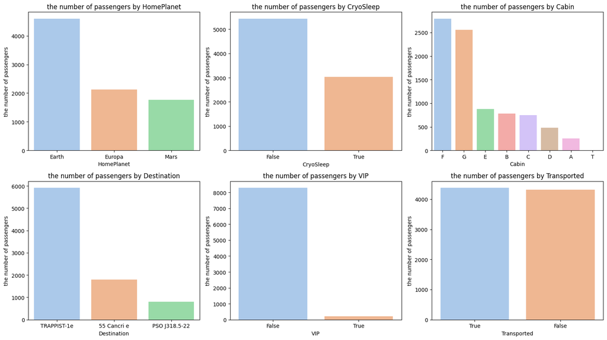

```python
fig, ax = plt.subplots(2, 3, figsize=(16, 9))

for i, col in enumerate(titanic_train_cat.columns):
    sns.countplot(x=col, data=titanic_train_cat, \
                  order=titanic_train_cat[col].value_counts().index,\
                  ax=ax[i//3, i%3])
    ax[i//3, i%3].set_title("the number of passengers by {}".format(col))
    ax[i//3, i%3].set_ylabel("the number of passengers")
    ax[i//3, i%3].set_xlabel("{}".format(col))

plt.tight_layout()
```

```python
transported = titanic_train['Transported'].value_counts()
print("Number of passengers transported:", \
    round(transported[0]/len(titanic_train)*100, 2), "%")
print("Number of passengers not transported:", \
    round(transported[1]/len(titanic_train)*100, 2), "%")
```

```
Number of passengers transported: 50.36 %
Number of passengers not transported: 49.64 %
```

## Numeric Features

```python
titanic_train_num = titanic_train.select_dtypes(include=['float64'])
titanic_train_num.head()
```

|  | Age | RoomService | FoodCourt | ShoppingMall | Spa | VRDeck |
| --- | --- | --- | --- | --- | --- | --- |
| 0 | 39.0 | 0.0 | 0.0 | 0.0 | 0.0 | 0.0 |
| 1 | 24.0 | 109.0 | 9.0 | 25.0 | 549.0 | 44.0 |
| 2 | 58.0 | 43.0 | 3576.0 | 0.0 | 6715.0 | 49.0 |
| 3 | 33.0 | 0.0 | 1283.0 | 371.0 | 3329.0 | 193.0 |
| 4 | 16.0 | 303.0 | 70.0 | 151.0 | 565.0 | 2.0 |

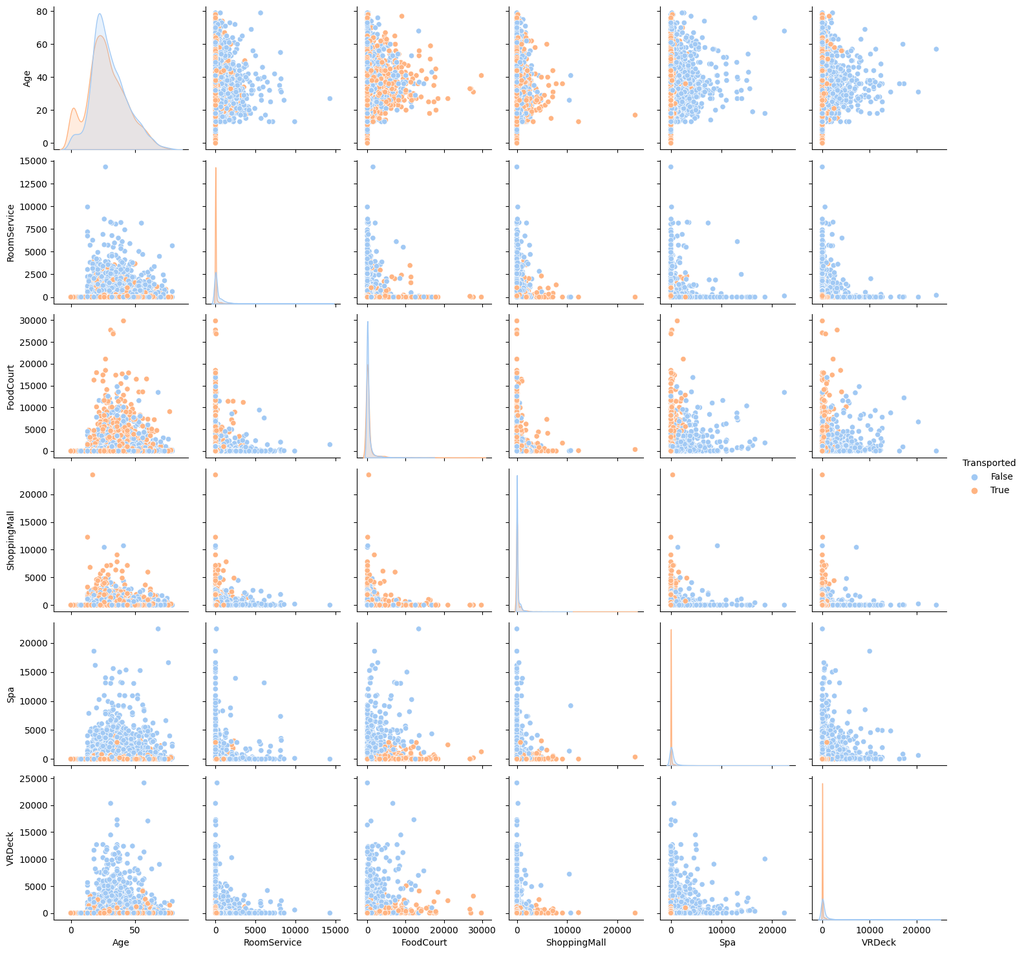

```python
titanic_train_num_trans = titanic_train_num.copy()
titanic_train_num_trans['Transported'] = titanic_train['Transported']

sns.pairplot(data=titanic_train_num_trans, hue='Transported')
```

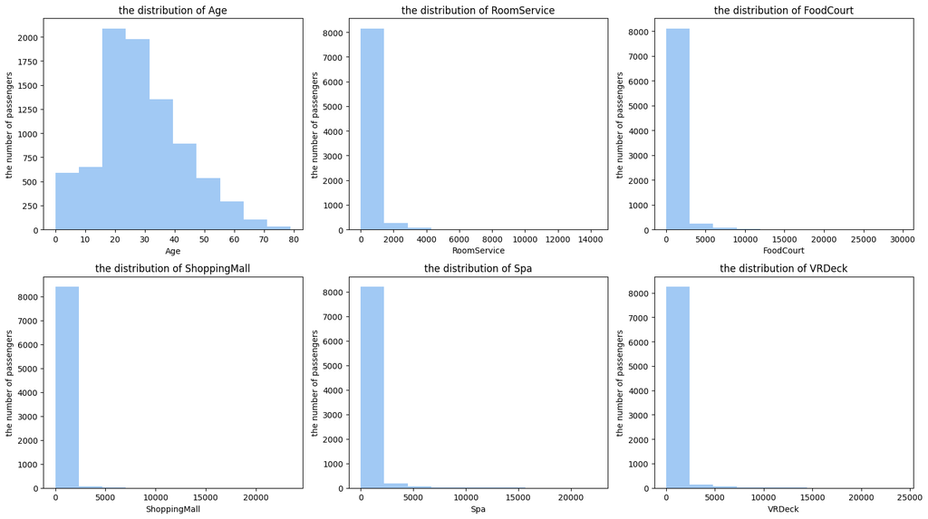

```python
fig, ax = plt.subplots(2, 3, figsize=(16, 9))

for i, col in enumerate(titanic_train_num.columns):
    titanic_train_num[col].plot(kind='hist', ax=ax[i//3, i%3])
    ax[i//3, i%3].set_title("the distribution of {}".format(col))
    ax[i//3, i%3].set_ylabel("the number of passengers")
    ax[i//3, i%3].set_xlabel("{}".format(col))

plt.tight_layout()
```

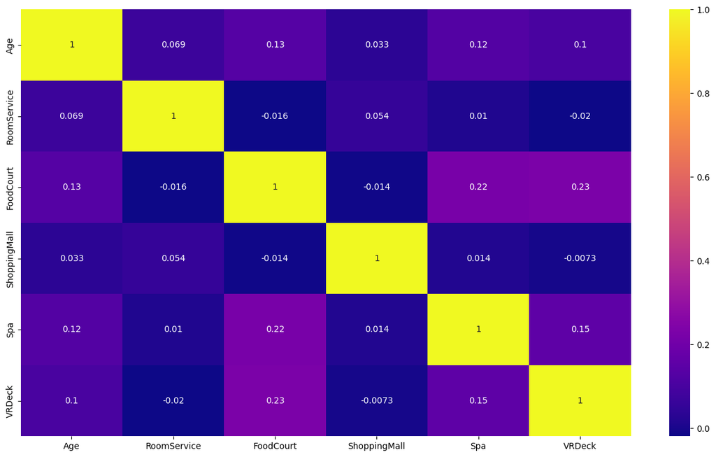

```python
plt.figure(figsize=(16, 9))
sns.heatmap(titanic_train_num.corr(), annot=True, cmap='plasma')
```

## My Explanation

- General Description:
  - Threr are 14 columns in total, containing id on each passenger and several features
  - Nearly all columns have null values, except `PassengerId` and "Transported"
- Categorial Features:
  - Most of the passengers come from Earth, not in cryoSleep, in cabin F, to TRAPPIST-1e, not VIP, and 50.36% of them are transported finally
  - The `Cabin` column need to be processed into 3 parts, i.e., `deck ,`num`,`side`, which may be helpful to the prediction
  - The `PassengerId` column follows the form of `gggg_pp`, i.e., where `gggg` indicates a group the passenger is travelling with and `pp` is their number within the group. They need to be seperated since it may matter.
- Numeric Features:
  - The pair plot clearly shows the relationship between the numeric features. By using the `Transported` for hue, it indicates the possible combinations which may be helpful in the featuring process
  - The `Age` are right-skewed
  - The heatmap indicated `FoodCourt` has the most positive relationship with `Spa` and `VRDeck`, and `VRDeck` has a most negative relationship with `RoomService`

# Train the Model

```python
from sklearn.pipeline import Pipeline
from sklearn.preprocessing import StandardScaler
from sklearn.impute import SimpleImputer
from sklearn.compose import ColumnTransformer
from sklearn.preprocessing import OrdinalEncoder, OneHotEncoder
```

First define the pipelines, both for numerical and categorical columns.

```python
num_pipeline = Pipeline([
    ('imputer', SimpleImputer(strategy='mean')),
    ('scaler', StandardScaler()),
    ])

cat_pipeline = Pipeline([
    ('imputer', SimpleImputer(strategy="most_frequent")),
    ('encoder', OneHotEncoder()),
    ])

num_attribs = list(titanic_train_num) + \
    ['Cabin_2', 'Consumption', 'id_group', 'vrdeck_vs_food', 'spa_vs_food', \
        'spa_vs_shopping', 'room_vs_shopping', 'vrdeck_vs_shopping']
cat_attribs = list(titanic_train_cat.drop(['Transported', 'Cabin'] ,axis=1))\
    + ['Cabin_1', 'Cabin_3', 'id_no']

full_pipeline = ColumnTransformer([
    ("num", num_pipeline, num_attribs),
    ("cat", cat_pipeline, cat_attribs),
    ])
```

Preprocess train set.

Here we preprocess "Cabin" and explode it, as well as add some additional features by combining a few numerical features.

```python
X_train = titanic_train.\
    drop(['PassengerId', 'Cabin', 'Name', 'Transported'], axis=1)
X_train['Cabin_1'] = titanic_train['Cabin'].\
    apply(lambda x: x.split('/')[0] if pd.notnull(x) else None)
X_train['Cabin_2'] = titanic_train['Cabin'].\
    apply(lambda x: x.split('/')[1] if pd.notnull(x) else None)
X_train['Cabin_3'] = titanic_train['Cabin'].\
    apply(lambda x: x.split('/')[2] if pd.notnull(x) else None)
X_train['Consumption'] = X_train['RoomService'] + X_train['FoodCourt'] + \
    X_train['ShoppingMall'] + X_train['Spa']
X_train['id_group'] = titanic_train['PassengerId'].\
    apply(lambda x: x.split('_')[0] if pd.notnull(x) else None)
X_train['id_no'] = titanic_train['PassengerId'].\
    apply(lambda x: x.split('_')[1] if pd.notnull(x) else None)
X_train['vrdeck_vs_food'] = X_train['VRDeck'] / (X_train['FoodCourt'] + 1)
X_train['vrdeck_vs_food'].replace(np.inf, None, inplace=True)
X_train['vrdeck_vs_shopping'] = X_train['VRDeck']/(X_train['ShoppingMall'] + 1)
X_train['vrdeck_vs_shopping'].replace(np.inf, None, inplace=True)
X_train['spa_vs_food'] = X_train['Spa'] / (X_train['FoodCourt'] + 1)
X_train['spa_vs_food'].replace(np.inf, None, inplace=True)
X_train['spa_vs_shopping'] = X_train['Spa'] / (X_train['ShoppingMall'] + 1)
X_train['spa_vs_shopping'].replace(np.inf, None, inplace=True)
X_train['room_vs_shopping'] = \
    X_train['RoomService']/(X_train['ShoppingMall'] + 1)
X_train['room_vs_shopping'].replace(np.inf, None, inplace=True)
# X_train.drop('Cabin', axis=1, inplace=True)
X_train.head()
```

|  | HomePlanet | CryoSleep | Destination | Age | VIP | RoomService | FoodCourt | ShoppingMall | Spa | VRDeck | ... | Cabin_2 | Cabin_3 | Consumption | id_group | id_no | vrdeck_vs_food | vrdeck_vs_shopping | spa_vs_food | spa_vs_shopping | room_vs_shopping |
| --- | --- | --- | --- | --- | --- | --- | --- | --- | --- | --- | --- | --- | --- | --- | --- | --- | --- | --- | --- | --- | --- |
| 0 | Europa | False | TRAPPIST-1e | 39.0 | False | 0.0 | 0.0 | 0.0 | 0.0 | 0.0 | ... | 0 | P | 0.0 | 0001 | 01 | 0.000000 | 0.000000 | 0.000000 | 0.000000 | 0.000000 |
| 1 | Earth | False | TRAPPIST-1e | 24.0 | False | 109.0 | 9.0 | 25.0 | 549.0 | 44.0 | ... | 0 | S | 692.0 | 0002 | 01 | 4.400000 | 1.692308 | 54.900000 | 21.115385 | 4.192308 |
| 2 | Europa | False | TRAPPIST-1e | 58.0 | True | 43.0 | 3576.0 | 0.0 | 6715.0 | 49.0 | ... | 0 | S | 10334.0 | 0003 | 01 | 0.013699 | 49.000000 | 1.877271 | 6715.000000 | 43.000000 |
| 3 | Europa | False | TRAPPIST-1e | 33.0 | False | 0.0 | 1283.0 | 371.0 | 3329.0 | 193.0 | ... | 0 | S | 4983.0 | 0003 | 02 | 0.150312 | 0.518817 | 2.592679 | 8.948925 | 0.000000 |
| 4 | Earth | False | TRAPPIST-1e | 16.0 | False | 303.0 | 70.0 | 151.0 | 565.0 | 2.0 | ... | 1 | S | 1089.0 | 0004 | 01 | 0.028169 | 0.013158 | 7.957746 | 3.717105 | 1.993421 |

5 rows × 21 columns

```python
X_train_formed = full_pipeline.fit_transform(X_train)
```

```python
y_train = titanic_train['Transported']
```

Preprocess test set.

```python
X_test = titanic_test.drop(['PassengerId', 'Cabin', 'Name'], axis=1)
X_test['Cabin_1'] = titanic_test['Cabin'].\
    apply(lambda x: x.split('/')[0] if pd.notnull(x) else None)
X_test['Cabin_2'] = titanic_test['Cabin'].\
    apply(lambda x: x.split('/')[1] if pd.notnull(x) else None)
X_test['Cabin_3'] = titanic_test['Cabin'].\
    apply(lambda x: x.split('/')[2] if pd.notnull(x) else None)
X_test['Consumption'] = X_test['RoomService'] + X_test['FoodCourt'] + \
    X_test['ShoppingMall'] + X_test['Spa']
X_test['id_group'] = titanic_test['PassengerId'].\
    apply(lambda x: x.split('_')[0] if pd.notnull(x) else None)
X_test['id_no'] = titanic_test['PassengerId'].\
    apply(lambda x: x.split('_')[1] if pd.notnull(x) else None)
X_test['vrdeck_vs_food'] = X_test['VRDeck'] / (X_test['FoodCourt'] + 1)
X_test['vrdeck_vs_food'].replace(np.inf, None, inplace=True)
X_test['vrdeck_vs_shopping'] = X_test['VRDeck'] / (X_test['ShoppingMall'] + 1)
X_test['vrdeck_vs_shopping'].replace(np.inf, None, inplace=True)
X_test['spa_vs_food'] = X_test['Spa'] / (X_test['FoodCourt'] + 1)
X_test['spa_vs_food'].replace(np.inf, None, inplace=True)
X_test['spa_vs_shopping'] = X_test['Spa'] / (X_test['ShoppingMall'] + 1)
X_test['spa_vs_shopping'].replace(np.inf, None, inplace=True)
X_test['room_vs_shopping'] = \
    X_test['RoomService'] / (X_test['ShoppingMall'] + 1)
X_test['room_vs_shopping'].replace(np.inf, None, inplace=True)
# X_test.drop('Cabin', axis=1, inplace=True)
X_test.head()
```

|  | HomePlanet | CryoSleep | Destination | Age | VIP | RoomService | FoodCourt | ShoppingMall | Spa | VRDeck | ... | Cabin_2 | Cabin_3 | Consumption | id_group | id_no | vrdeck_vs_food | vrdeck_vs_shopping | spa_vs_food | spa_vs_shopping | room_vs_shopping |
| --- | --- | --- | --- | --- | --- | --- | --- | --- | --- | --- | --- | --- | --- | --- | --- | --- | --- | --- | --- | --- | --- |
| 0 | Earth | True | TRAPPIST-1e | 27.0 | False | 0.0 | 0.0 | 0.0 | 0.0 | 0.0 | ... | 3 | S | 0.0 | 0013 | 01 | 0.00000 | 0.0 | 0.000000 | 0.0 | 0.000000 |
| 1 | Earth | False | TRAPPIST-1e | 19.0 | False | 0.0 | 9.0 | 0.0 | 2823.0 | 0.0 | ... | 4 | S | 2832.0 | 0018 | 01 | 0.00000 | 0.0 | 282.300000 | 2823.0 | 0.000000 |
| 2 | Europa | True | 55 Cancri e | 31.0 | False | 0.0 | 0.0 | 0.0 | 0.0 | 0.0 | ... | 0 | S | 0.0 | 0019 | 01 | 0.00000 | 0.0 | 0.000000 | 0.0 | 0.000000 |
| 3 | Europa | False | TRAPPIST-1e | 38.0 | False | 0.0 | 6652.0 | 0.0 | 181.0 | 585.0 | ... | 1 | S | 6833.0 | 0021 | 01 | 0.08793 | 585.0 | 0.027206 | 181.0 | 0.000000 |
| 4 | Earth | False | TRAPPIST-1e | 20.0 | False | 10.0 | 0.0 | 635.0 | 0.0 | 0.0 | ... | 5 | S | 645.0 | 0023 | 01 | 0.00000 | 0.0 | 0.000000 | 0.0 | 0.015723 |

5 rows × 21 columns

```python
X_test_formed = full_pipeline.fit_transform(X_test)
```

## Naive Bayes

```python
from sklearn.naive_bayes import GaussianNB

model_nb = GaussianNB()
model_nb.fit(X_train_formed, y_train)
```

```
GaussianNB()
```

```python
y_pred = model_nb.predict(X_train_formed)
y_pred
```

```
array([ True,  True, False, ...,  True, False,  True])
```

```python
from sklearn.metrics import accuracy_score
from sklearn.metrics import classification_report, confusion_matrix
from sklearn.model_selection import cross_val_score
```

```python
def display_scores(scores):
    print("Accuracy: %0.2f%% (+/- %0.2f)" % (scores.mean()*100, scores.std() * 2*100))
```

```python
nb_scores = cross_val_score(model_nb, X_train_formed, y_train, cv=10)
display_scores(nb_scores)
```

```
Accuracy: 69.63% (+/- 4.88)
```

## Support Vector Machines

```python
from sklearn import svm
```

```python
from sklearn.model_selection import GridSearchCV
param_grid = {
    'random_state': [42],
    'kernel': ['linear', 'rbf'],
     'C': [0.1, 1, 5],
    'gamma': [0.1, 1]
}
```

```python
model_svm = svm.SVC(probability=True)
grid_svm = GridSearchCV(model_svm, param_grid, cv=10, n_jobs=-1)
grid_svm.fit(X_train_formed, y_train)
```

```
GridSearchCV(cv=10, estimator=SVC(probability=True), n_jobs=-1,
             param_grid={'C': [0.1, 1, 5], 'gamma': [0.1, 1],
                         'kernel': ['linear', 'rbf'], 'random_state': [42]})
```

```python
grid_svm.best_params_
```

```
{'C': 1, 'gamma': 0.1, 'kernel': 'rbf', 'random_state': 42}
```

```python
model_svm = grid_svm.best_estimator_
```

```python
svm_scores = cross_val_score(model_svm, X_train_formed, y_train, cv=10)
display_scores(svm_scores)
```

```
Accuracy: 80.46% (+/- 4.11)
```

## Decision Trees

```python
from sklearn.tree import DecisionTreeClassifier

model_dt = DecisionTreeClassifier()
model_dt
```

```
DecisionTreeClassifier()
```

```python
param_grid = {
    "random_state": [42],
    "criterion": ['gini', 'entropy'],
    "splitter": ['best'],
    "max_depth": [3, 5, 10, 15, 20],
    "min_samples_split": [2, 3, 5, 10, 15, 20, 30, 40, 50, 60]
}
```

```python
grid_dt = GridSearchCV(model_dt, param_grid, cv=10, n_jobs=-1)
grid_dt.fit(X_train_formed, y_train)
```

```
GridSearchCV(cv=10, estimator=DecisionTreeClassifier(), n_jobs=-1,
             param_grid={'criterion': ['gini', 'entropy'],
                         'max_depth': [3, 5, 10, 15, 20],
                         'min_samples_split': [2, 3, 5, 10, 15, 20, 30, 40, 50,
                                               60],
                         'random_state': [42], 'splitter': ['best']})
```

```python
grid_dt.best_params_
```

```
{'criterion': 'gini',
 'max_depth': 5,
 'min_samples_split': 2,
 'random_state': 42,
 'splitter': 'best'}
```

```python
model_dt = grid_dt.best_estimator_
```

```python
display_scores(cross_val_score(model_dt, X_train_formed, y_train, cv=10))
```

```
Accuracy: 76.72% (+/- 7.46)
```

## Random Forest

```python
from sklearn.ensemble import RandomForestClassifier
model_rf = RandomForestClassifier()
```

```python
param_grid = {
    'random_state': [42],
    'criterion': ['gini', 'entropy'],
    'n_estimators': [10, 15, 20, 25, 30, 35, 40, 50, 90, 95, 100, 105, 110,\
        120],
    'max_depth': [2, 5, 7, 9, 11, 13, 15],
}
```

```python
grid_rf = GridSearchCV(model_rf, param_grid, cv=10, n_jobs=-1)
grid_rf.fit(X_train_formed, y_train)
```

```
GridSearchCV(cv=10, estimator=RandomForestClassifier(), n_jobs=-1,
             param_grid={'criterion': ['gini', 'entropy'],
                         'max_depth': [2, 5, 7, 9, 11, 13, 15],
                         'n_estimators': [10, 15, 20, 25, 30, 35, 40, 50, 90,
                                          95, 100, 105, 110, 120],
                         'random_state': [42]})
```

```python
grid_rf.best_params_
```

```
{'criterion': 'gini', 'max_depth': 9, 'n_estimators': 35, 'random_state': 42}
```

```python
model_rf = grid_rf.best_estimator_
model_rf
```

```
RandomForestClassifier(max_depth=9, n_estimators=35, random_state=42)
```

```python
display_scores(cross_val_score(model_rf, X_train_formed, y_train, cv=10))
```

```
Accuracy: 79.51% (+/- 3.95)
```

## Adaboost

```python
from sklearn.ensemble import AdaBoostClassifier

model_ada = AdaBoostClassifier(estimator=None)
```

```python
param_grid = {
    'random_state': [42],
    "n_estimators": [10, 15, 20, 25, 30, 35, 40],
    "learning_rate": [0.1, 0.5, 1, 1.5, 2],
}
```

```python
grid_ada = GridSearchCV(model_ada, param_grid, cv=10, n_jobs=-1)
grid_ada.fit(X_train_formed, y_train)
```

```
GridSearchCV(cv=10, estimator=AdaBoostClassifier(), n_jobs=-1,
             param_grid={'learning_rate': [0.1, 0.5, 1, 1.5, 2],
                         'n_estimators': [10, 15, 20, 25, 30, 35, 40],
                         'random_state': [42]})
```

```python
grid_ada.best_params_
```

```
{'learning_rate': 0.5, 'n_estimators': 20, 'random_state': 42}
```

```python
model_ada = grid_ada.best_estimator_
```

```python
display_scores(cross_val_score(model_ada, X_train_formed, y_train, cv=10))
```

```
Accuracy: 77.82% (+/- 2.80)
```

## Voting

```python
from sklearn.ensemble import VotingClassifier
```

```python
voting_clf = VotingClassifier(
    estimators=[('nb', model_nb), ('svm', model_svm), \
        ('dt', model_dt), ('rf', model_rf), ('ada', model_ada)], \
        voting='soft')
```

```python
voting_clf.fit(X_train_formed, y_train)
```

```
VotingClassifier(estimators=[('nb', GaussianNB()),
                             ('svm',
                              SVC(C=1, gamma=0.1, probability=True,
                                  random_state=42)),
                             ('dt',
                              DecisionTreeClassifier(max_depth=5,
                                                     random_state=42)),
                             ('rf',
                              RandomForestClassifier(max_depth=9,
                                                     n_estimators=35,
                                                     random_state=42)),
                             ('ada',
                              AdaBoostClassifier(learning_rate=0.5,
                                                 n_estimators=20,
                                                 random_state=42))],
                 voting='soft')
```

```python
voting_clf.get_params()
```

```
{'estimators': [('nb', GaussianNB()),
  ('svm', SVC(C=1, gamma=0.1, probability=True, random_state=42)),
  ('dt', DecisionTreeClassifier(max_depth=5, random_state=42)),
  ('rf',
   RandomForestClassifier(max_depth=9, n_estimators=35, random_state=42)),
  ('ada',
   AdaBoostClassifier(learning_rate=0.5, n_estimators=20, random_state=42))],
 'flatten_transform': True,
 'n_jobs': None,
 'verbose': False,
 'voting': 'soft',
 'weights': None,
 'nb': GaussianNB(),
 'svm': SVC(C=1, gamma=0.1, probability=True, random_state=42),
 'dt': DecisionTreeClassifier(max_depth=5, random_state=42),
 'rf': RandomForestClassifier(max_depth=9, n_estimators=35, random_state=42),
 'ada': AdaBoostClassifier(learning_rate=0.5, n_estimators=20, random_state=42),
 'nb__priors': None,
 'nb__var_smoothing': 1e-09,
 'svm__C': 1,
 'svm__break_ties': False,
 'svm__cache_size': 200,
 'svm__class_weight': None,
 'svm__coef0': 0.0,
 'svm__decision_function_shape': 'ovr',
 'svm__degree': 3,
 'svm__gamma': 0.1,
 'svm__kernel': 'rbf',
 'svm__max_iter': -1,
 'svm__probability': True,
 'svm__random_state': 42,
 'svm__shrinking': True,
 'svm__tol': 0.001,
 'svm__verbose': False,
 'dt__ccp_alpha': 0.0,
 'dt__class_weight': None,
 'dt__criterion': 'gini',
 'dt__max_depth': 5,
 'dt__max_features': None,
 'dt__max_leaf_nodes': None,
```

[output cut: 15 more lines]

```
 'rf__min_samples_leaf': 1,
 'rf__min_samples_split': 2,
 'rf__min_weight_fraction_leaf': 0.0,
 'rf__n_estimators': 35,
 'rf__n_jobs': None,
 'rf__oob_score': False,
 'rf__random_state': 42,
 'rf__verbose': 0,
 'rf__warm_start': False,
 'ada__algorithm': 'SAMME.R',
 'ada__base_estimator': 'deprecated',
 'ada__estimator': None,
 'ada__learning_rate': 0.5,
 'ada__n_estimators': 20,
 'ada__random_state': 42}
```

```python
display_scores(cross_val_score(voting_clf, X_train_formed, y_train, cv=10))
```

```
Accuracy: 79.34% (+/- 3.25)
```

```python
y_test = voting_clf.predict(X_test_formed)
y_test
```

```
array([ True, False,  True, ...,  True,  True,  True])
```

```python
save_file = pd.DataFrame({'PassengerId': titanic_test['PassengerId'], \
    'Transported': y_test})
save_file.to_csv('my_submission.csv', index=False)
```

# Conclusion

The result gets a score of **80.196%** on *Kaggle*